# **Investigating Trends Across Video Games with Steam Data**

## **Jamari Ross & Sophie Leff**

**Github Web Page:** https://sleff22.github.io/CMPS-3160/

## **Links**

Below are various links to other parts of our project, including our Github and slides.

**Github:** https://github.com/sleff22/CMPS-3160

**Milestone 1:** https://colab.research.google.com/drive/1tx-s_51ZsaE76XxECL3M3WFzYNSwJpXq?usp=sharing

**Presentation Slides:** https://canva.link/exv86p03n8f0fbj

# **Motivation**

We want to start this of by saying that we both love video games. After partnering together, we spent a solid 45 minutes just talking about the various games that we have and haven't played before discussing the project itself. While trying to come up with a good question for our tutorial, we realized a few key issues:

- A lot of data that we would want to work with is very decentralized and scattered on various places on the internet
- Data that we **could** find was often outdated or obsolete, making it nearly useless in any data analysis we could do
- Much of the current professional analysis focuses on revenue of games and/or companies, and rarely transform this data in a way that it could be paired with other features to answer other questions

Video gaming is a $190+ billion dollar industry, and the platform, Steam, alone has over 130,000 games published on it. We know there are countless data metrics being measured every day, and yet that data is so difficult to find and compile. Therefore, we decided we would undertake the task of compiling the more up-to-date information and datasets available to us, and do a lot of estimations and comparisons between features of video games to answer a number of smaller questions. While we will only be using a smaller part of the data that exists, having the ability to build smaller models that can be scaleld and applied to larger sets of data could help bridge the gap in analytics available for video games.

### **Goal & Questions**

The goal of this tutorial was to analyze different data points across games on the publishing platform, Steam, and make connections between what makes them popular, player demographics, and common denominators between games that win awards (among other things).

Rather than focusing on one larger question we split the project up into many smaller questions we investigated. In our metrics and data sections we show graphs and visualizations for a variety of different metrics such as:

- Game pricing and popularity across genres, themes, publishers, etc
- Correlation between metacritic score and pricing
- Genre and ownership counts

For the final model we chose to attempt to predict a games estimated revenue based off its main genre, price, and metacritic score. For reasons we explain below, this is a very complicated problem with many things to consider so rather than attempting to build several independent models we focused specifically on this goal. We ended up creating two models to show how a simple approach does not always fit skewed and difficult data, and how data scientists can improve their model accuracy by using different algorithms or data preprocessing techniques.

### **Datasets**

In this project, the two datasets we used were:

- [Kaggle Steam Games Dataset](https://www.kaggle.com/datasets/fronkongames/steam-games-dataset)
- [SteamSpy](https://steamspy.com/api.php)

With these datasets, we are confident we will be able to make connections between data to answer our many questions. For example, one of the questions we will be exploring is the correlation between Steam game statistics (genres, price, player demographics, etc.).

### **Collaboration Plan**

Both of us were very involved in each step of the data collection, cleaning, and visualization process. While we both have strengths and weaknesses in certain areas, we used our skills (and Google) to bridge any possible gaps within our process.

Throughout the tutorial, Jamari worked on analyzing relevant and interesting statistics for us to look at (EDA) as well as graphics and visualization, while Sophie worked on dataset collection and dataset cleaning (ETL) and developing the final version of our revenue prediction models. We both communicated while working and kept each other updated on exactly what we were doing. Even though our focus was on separate parts of the process, we are made sure that we still collaborated and contributed to the other's workload when necessary.

We both collaborated on building the models, doing our final observations, and creating both deliverables.

# **Data Collection and Data Cleaning Part 1**

I (Sophie) started working on loading and cleaning up the Kaggle dataset. It has lots of categories from basic info about the games to reviews, prices, etc. So far I have chosen several categories to isolate (important ones like names, developers, prices, ratings, etc). I am also coming up with questions about the dataset that we need to tackle such as how to manage names with non-english characters, "null" games (ones that have no information), etc.

Because the initial dataset was extremely large, I had to do the actual ETL outside of Colab to ensure we didn't reach our storage limit on Colab. The original and cleaned up datasets, and the script I wrote to clean them can be found in our [GitHub](https://github.com/sleff22/CMPS-3160), but a commented version of the Python script well be pasted below.

```python
# # Simple parse of the 'games.json' file.
# import os
# import json
# import pandas as pd

# dataset = {}
# if os.path.exists('games.json'):
#   with open('games.json', 'r', encoding='utf-8') as fin:
#     text = fin.read()
#     if len(text) > 0:
#       dataset = json.loads(text)


# rows = []
# for app in dataset:
#     game = dataset[app]

#     if game['price'] != 0:
#        continue


#     if 'English' not in game['supported_languages']:
#        continue

#     if game['metacritic_score'] == 0:
#        continue



#     rows.append({
#         'appID': app,
#         'name': game['name'],
#         'release_date': game['release_date'],
#         'price': game['price'],
#         'supported_languages': game['supported_languages'],
#         'developers': ', '.join(game['developers']),
#         'publishers': ', '.join(game['publishers']),
#         'categories': ', '.join(game['categories']),
#         'genres': ', '.join(game['genres']),
#         'tags': ', '.join(str(t) for t in game['tags']),
#         'metacriticScore': game['metacritic_score']
#     })

# df = pd.DataFrame(rows)
# df.to_csv('total_output.csv', index=False)
```

```python
# importing our files from our GitHub repository
!git clone https://github.com/sleff22/CMPS-3160.git
```

```
fatal: destination path 'CMPS-3160' already exists and is not an empty directory.
```

# **Exploratory Data Analysis Part 1**

After doing the ETL, pulling some statistics and creating a visualization was fairly straightforward. In the cells below, I (Jamari) loaded our clean datasets into the games_paid variable, and started adding a few more columns that would help categorize these games in the future and help with some summary statistics. This mainly consisted of getting the general price range of each game as well as getting their main genre, since most of the games have multiple genres listed.

```python
#Mounting to drive to later export the html file of the notebook
from google.colab import drive
drive.mount('/content/drive')
```

```python
import pandas as pd

#Read and assign the first cleaned dataset that we cloned from github. Set 1 consists of paid games, set 2 consists of free-to-play games.
games_paid = pd.read_csv("../content/CMPS-3160/Kaggle_Cleaned_Set1.csv")

games_paid.head()
```

|  | appID | name | release_date | price | supported_languages | developers | publishers | categories | genres | tags | metacriticScore |
| --- | --- | --- | --- | --- | --- | --- | --- | --- | --- | --- | --- |
| 0 | 1025440 | Fantasy General II | Sep 5, 2019 | 13.99 | ['English', 'German', 'Spanish - Spain', 'Simp... | Owned by Gravity | Slitherine Ltd. | Single-player, Multi-player, PvP, Online PvP, ... | Strategy | Strategy, Turn-Based Strategy, Fantasy, Turn-B... | 80 |
| 1 | 416790 | The Metronomicon: Slay The Dance Floor | Sep 29, 2016 | 4.99 | ['English', 'French', 'Italian', 'German', 'Sp... | Puuba | Akupara Games | Single-player, Multi-player, PvP, Shared/Split... | Action, Indie, RPG | Rhythm, Music, Indie, Soundtrack, Singleplayer... | 79 |
| 2 | 672230 | I fell from Grace | Dec 20, 2017 | 0.79 | ['English'] | Deep Taiga | Deep Taiga | Single-player, Steam Achievements, Partial Con... | Adventure, Indie | Adventure, Indie, Gore, Violent, Choices Matte... | 62 |
| 3 | 1110050 | Evan's Remains | Jun 11, 2020 | 1.39 | ['English', 'French', 'Italian', 'German', 'Ja... | maitan69 | Whitethorn Games | Single-player, Steam Achievements, Full contro... | Adventure, Casual, Indie | Casual, Puzzle-Platformer, Visual Novel, Femal... | 75 |
| 4 | 715560 | Eastshade | Feb 13, 2019 | 9.99 | ['English', 'French', 'German', 'Russian', 'Si... | Eastshade Studios | Eastshade Studios | Single-player, Steam Achievements, Full contro... | Adventure, Indie | Exploration, Relaxing, Open World, Beautiful, ... | 78 |

```python
from os import name
from numpy import nan

#Create a price range column to simplify plotting later on
price_val = games_paid["price"]
games_paid['price range'] = "Not Assigned"

#Create and assign the price ranges based on pricing criteria
games_paid.loc[price_val < 10, 'price range'] = "Less than $9.99"
games_paid.loc[(price_val <20) & (price_val >= 10), 'price range'] = "$10 - $19.99"
games_paid.loc[(price_val < 40) & (price_val >= 20), 'price range'] = "$20 - $39.99"
games_paid.loc[price_val >= 40, 'price range'] = "$40+"
```

```python
''' Created a function to get the main genre (first index of genre as categorized by Steam) for each game. For the purposes of our research, we will
not count "Indie" as a game genre, but as a way to categorize the production of certain games (Indie, AA, AAA, etc.)
Therefore, if a game's main genre is Indie, we skip over it and use the next genre in the list.'''

def get_main_genre(game):
  if game is nan:
    return

  genres = game.split(',')

  if (str(genres[0]).upper == "INDIE") & (len(genres) > 1): #Some Indie observations will make it into the genre list if it is their only genre listed
    main_g = genres[1]
  else:
    main_g = genres[0]

  return str.strip(main_g) #Returns the genre, stripped of spaces in the front and back of the string

#Apply the function to create the new column "main genre"
games_paid['main genre'] = games_paid['genres'].apply(get_main_genre)
genre_list = games_paid['main genre'].unique() #Lists all the genres gathered form the dataset
```

```python
''' Created a filtered DataFrame containing games that are not categorized as Indie. This is to account for the fact that
many indie games are typically priced under $20, which could visually skew plots. I separated them for easier comparison, just in case I need them'''

non_indie = games_paid.loc[~games_paid['genres'].str.contains("Indie", na=False), ["name", "price", "main genre", "price range"]].reset_index()
indie = games_paid.loc[games_paid['genres'].str.contains("Indie", na=False), ["name", "price", "main genre", "genres", "price range"]].reset_index()


#Create a new DataFrame with simplified and relevant statistics
new_gp = games_paid[['name', 'price', 'price range', 'main genre', 'metacriticScore']]

#Some summary statistic graphs like counts by genre, and by indie/on-indie types
genre_counts = new_gp.groupby('main genre')['price range'].value_counts().unstack().fillna(0).astype(int)[['Less than $9.99', '$10 - $19.99', '$20 - $39.99', '$40+']]
game_counts = pd.DataFrame([
    indie['name'].count(),
    non_indie['name'].count()],
    index=["Indie games", "Non-Indie games"],
    columns=["Count"])
```

```python
#Checking the data types of each column, as well as any missing/null data

display(new_gp.dtypes)
display(new_gp.isnull().sum())
```

|  | 0 |
| --- | --- |
| name | object |
| price | float64 |
| price range | object |
| main genre | object |
| metacriticScore | int64 |

**dtype:** object

|  | 0 |
| --- | --- |
| name | 0 |
| price | 0 |
| price range | 0 |
| main genre | 7 |
| metacriticScore | 0 |

**dtype:** int64

### **A Few Interesting Metrics**

#### **Pricing summary across all genres**

Here we can check the average game price for each genre across both indie and non-indie games, which shows us that Sports has the highest average game price, at $14.99 USD, while Sexual Content has the lowest at about $3.14 USD.

```python
#Group by genres and get the average price of each category
new_gp.groupby('main genre')['price'].mean().sort_values(ascending=False)
```

| main genre | price |
| --- | --- |
| Sports | 14.990000 |
| Massively Multiplayer | 13.740000 |
| Simulation | 8.307293 |
| RPG | 8.083684 |
| Violent | 7.990000 |
| Action | 7.226537 |
| Racing | 6.728372 |
| Casual | 6.576516 |
| Adventure | 6.487497 |
| Indie | 6.339482 |
| Strategy | 5.712111 |
| Nudity | 5.190000 |
| Sexual Content | 3.140000 |

**dtype:** float64

#### **Metacritic score summary across all genres**

Similarly, we can also calculate the average metacritic score for each game genre.

We can see that MMOs (Massively Multiplayer) games have the highest average score at 81, while Nudity has the lowest at 54.

```python
#Group by genre and get the average score of each category
new_gp.groupby('main genre')['metacriticScore'].mean().sort_values(ascending=False)
```

| main genre | metacriticScore |
| --- | --- |
| Massively Multiplayer | 81.000000 |
| RPG | 75.927632 |
| Strategy | 75.135678 |
| Sports | 74.500000 |
| Indie | 74.097561 |
| Adventure | 74.059003 |
| Casual | 74.045161 |
| Sexual Content | 74.000000 |
| Action | 73.609780 |
| Simulation | 72.932331 |
| Racing | 70.372093 |
| Violent | 66.250000 |
| Nudity | 54.000000 |

**dtype:** float64

It should be noted that some of the genres have a lower amount of observations compared to others. Let's try filtering it by genres with 30 or more games that have that category listed as its main genre.

```python
#Get the genres that have more than 30 observations
counts = new_gp['main genre'].value_counts()
filtered_counts = counts[counts >= 30].index

#Filter and take the games who's main genre is in the filtered categories
filtered_genres = new_gp[new_gp['main genre'].isin(filtered_counts)]

#Group by genre and get the average of the metacritic scores of the filtered values
filtered_genres.groupby('main genre')["metacriticScore"].mean().sort_values(ascending=False)
```

| main genre | metacriticScore |
| --- | --- |
| RPG | 75.927632 |
| Strategy | 75.135678 |
| Indie | 74.097561 |
| Adventure | 74.059003 |
| Casual | 74.045161 |
| Action | 73.609780 |
| Simulation | 72.932331 |
| Racing | 70.372093 |

**dtype:** float64

After filtering the values, we can see that RPG has the highest average score (75.92) of categories with more than 30 reviews, while Racing has the lowest at 70.37. We can do this same thing for price.

```python
#Group by genre and get the average of the metacritic scores of the filtered values
filtered_genres.groupby('main genre')["price"].mean().sort_values(ascending=False)
```

| main genre | price |
| --- | --- |
| Simulation | 8.307293 |
| RPG | 8.083684 |
| Action | 7.226537 |
| Racing | 6.728372 |
| Casual | 6.576516 |
| Adventure | 6.487497 |
| Indie | 6.339482 |
| Strategy | 5.712111 |

**dtype:** float64

#### **Metacritic Score based on game pricing**

One of the easiest statistics to visualize with our current data is the distribution of the Metacritic Score fluctuates based on game pricing. The Metacritic Score is a value (score) given to a game based on numerous criteria by verified reviewers from the Metacritic organization. If you'd like to learn more about how they weigh scores, you can take a look at the Wikipedia article for it [here](https://en.wikipedia.org/wiki/Metacritic).

```python
#Metric 3: Price and Metacritic Score correlation

''' We can see here that there's a very low correlation between price and metacriticScore, which means that
price has very little impact on the scoring of the game this is further demonstrated by the scatterplot below.'''

new_gp[['price', 'metacriticScore']].corr()
```

|  | price | metacriticScore |
| --- | --- | --- |
| price | 1.000000 | 0.183505 |
| metacriticScore | 0.183505 | 1.000000 |

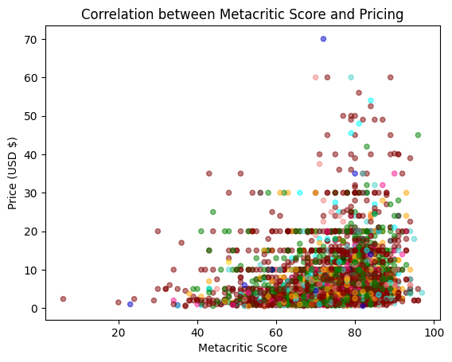

```python
#Map all the genres to a color
genre_colors = new_gp['main genre'].map({
    "Strategy" : "lightcoral",
    "Action" : "maroon",
    "Adventure" : "green",
    "Simulation" : "cyan",
    "Casual" : "deeppink",
    "Indie" : "orange",
    "Massively Multiplayer" : "darkviolet",
    "Racing" : "mediumblue",
    "RPG" : "mediumturquoise",
    "Sports" : "darkolivegreen",
    "Sexual Content" : "crimson",
    "Violent" : "gold",
    "Nudity" : "slategray",
    None : "black"
    })


new_gp.plot.scatter(y = "price", x = "metacriticScore", c = genre_colors, alpha = 0.5,
                    title = "Correlation between Metacritic Score and Pricing",
                    xlabel = "Metacritic Score", ylabel = "Price (USD $)", legend = True)
```

Here in the scatterplot, we can see that there isn't a noticeable trend among the data, supporting the low correlation calculated earlier.

# **Data Collection and Data Cleaning Part 2**

At this step we brought in data from the SteamSpy dataset to access metrics such as estimated revenue and ownership numbers. This was done through API queries from the SteamSpy website.

```python
from google.colab import drive
import pandas as pd

#This code is commented out because it was only necessary for data downloading/cleaning

#Mount drive to save data
#drive.mount('/content/drive')

#Path to use
#save_path = "/content/drive/MyDrive/SteamSpyResults.json"

url = "https://raw.githubusercontent.com/sleff22/CMPS-3160/refs/heads/main/Kaggle_Cleaned_Set1.csv"
df = pd.read_csv(url)

display(df)
```

|  | appID | name | release_date | price | supported_languages | developers | publishers | categories | genres | tags | metacriticScore |
| --- | --- | --- | --- | --- | --- | --- | --- | --- | --- | --- | --- |
| 0 | 1025440 | Fantasy General II | Sep 5, 2019 | 13.99 | ['English', 'German', 'Spanish - Spain', 'Simp... | Owned by Gravity | Slitherine Ltd. | Single-player, Multi-player, PvP, Online PvP, ... | Strategy | Strategy, Turn-Based Strategy, Fantasy, Turn-B... | 80 |
| 1 | 416790 | The Metronomicon: Slay The Dance Floor | Sep 29, 2016 | 4.99 | ['English', 'French', 'Italian', 'German', 'Sp... | Puuba | Akupara Games | Single-player, Multi-player, PvP, Shared/Split... | Action, Indie, RPG | Rhythm, Music, Indie, Soundtrack, Singleplayer... | 79 |
| 2 | 672230 | I fell from Grace | Dec 20, 2017 | 0.79 | ['English'] | Deep Taiga | Deep Taiga | Single-player, Steam Achievements, Partial Con... | Adventure, Indie | Adventure, Indie, Gore, Violent, Choices Matte... | 62 |
| 3 | 1110050 | Evan's Remains | Jun 11, 2020 | 1.39 | ['English', 'French', 'Italian', 'German', 'Ja... | maitan69 | Whitethorn Games | Single-player, Steam Achievements, Full contro... | Adventure, Casual, Indie | Casual, Puzzle-Platformer, Visual Novel, Femal... | 75 |
| 4 | 715560 | Eastshade | Feb 13, 2019 | 9.99 | ['English', 'French', 'German', 'Russian', 'Si... | Eastshade Studios | Eastshade Studios | Single-player, Steam Achievements, Full contro... | Adventure, Indie | Exploration, Relaxing, Open World, Beautiful, ... | 78 |
| ... | ... | ... | ... | ... | ... | ... | ... | ... | ... | ... | ... |
| 4012 | 50000 | Nimbus | Oct 25, 2010 | 2.49 | ['English'] | Noumenon Games | NaN | Single-player, Steam Achievements, Partial Con... | Indie, Racing | Indie, Racing, Puzzle, Physics, Difficult, Pla... | 80 |
| 4013 | 494670 | TransRoad: USA | Nov 9, 2017 | 3.99 | ['English', 'French', 'German', 'Spanish - Spa... | Deck13 Hamburg | astragon Entertainment | Single-player, Steam Achievements, Steam Tradi... | Casual, Simulation, Strategy | Simulation, Automobile Sim, Strategy, Casual, ... | 53 |
| 4014 | 1399700 | Kapital: Sparks of Revolution | Apr 28, 2022 | 2.99 | ['English', 'Russian', 'German', 'Simplified C... | Lapovich Team | Fulqrum Publishing | Single-player, Steam Achievements, Steam Cloud... | Indie, Simulation, Strategy | Strategy, City Builder, Economy, Capitalism, S... | 64 |
| 4015 | 227100 | Sniper Elite: Nazi Zombie Army | Feb 28, 2013 | 2.24 | ['English', 'French', 'German', 'Italian', 'Sp... | Rebellion | Rebellion | Single-player, Multi-player, Co-op, Steam Achi... | Action | Zombies, Action, Co-op, Sniper, World War II, ... | 62 |
| 4016 | 676820 | Subsurface Circular | Aug 17, 2017 | 2.99 | ['English'] | Bithell Games | Bithell Games | Single-player, Steam Achievements, Steam Cloud... | Adventure, Casual, Indie | Visual Novel, Investigation, Detective, Choice... | 83 |

4017 rows × 11 columns

```python
df_new = df.copy()
#Gets date format into just year
df_new['release_date'] = pd.to_datetime(df_new['release_date']).dt.year
#Gets games from 2008 or after
df_new = df_new[df_new['release_date'] > 2008]
display(df_new)
df_new.to_csv('2009Games.csv', index=False)
```

|  | appID | name | release_date | price | supported_languages | developers | publishers | categories | genres | tags | metacriticScore |
| --- | --- | --- | --- | --- | --- | --- | --- | --- | --- | --- | --- |
| 0 | 1025440 | Fantasy General II | 2019 | 13.99 | ['English', 'German', 'Spanish - Spain', 'Simp... | Owned by Gravity | Slitherine Ltd. | Single-player, Multi-player, PvP, Online PvP, ... | Strategy | Strategy, Turn-Based Strategy, Fantasy, Turn-B... | 80 |
| 1 | 416790 | The Metronomicon: Slay The Dance Floor | 2016 | 4.99 | ['English', 'French', 'Italian', 'German', 'Sp... | Puuba | Akupara Games | Single-player, Multi-player, PvP, Shared/Split... | Action, Indie, RPG | Rhythm, Music, Indie, Soundtrack, Singleplayer... | 79 |
| 2 | 672230 | I fell from Grace | 2017 | 0.79 | ['English'] | Deep Taiga | Deep Taiga | Single-player, Steam Achievements, Partial Con... | Adventure, Indie | Adventure, Indie, Gore, Violent, Choices Matte... | 62 |
| 3 | 1110050 | Evan's Remains | 2020 | 1.39 | ['English', 'French', 'Italian', 'German', 'Ja... | maitan69 | Whitethorn Games | Single-player, Steam Achievements, Full contro... | Adventure, Casual, Indie | Casual, Puzzle-Platformer, Visual Novel, Femal... | 75 |
| 4 | 715560 | Eastshade | 2019 | 9.99 | ['English', 'French', 'German', 'Russian', 'Si... | Eastshade Studios | Eastshade Studios | Single-player, Steam Achievements, Full contro... | Adventure, Indie | Exploration, Relaxing, Open World, Beautiful, ... | 78 |
| ... | ... | ... | ... | ... | ... | ... | ... | ... | ... | ... | ... |
| 4012 | 50000 | Nimbus | 2010 | 2.49 | ['English'] | Noumenon Games | NaN | Single-player, Steam Achievements, Partial Con... | Indie, Racing | Indie, Racing, Puzzle, Physics, Difficult, Pla... | 80 |
| 4013 | 494670 | TransRoad: USA | 2017 | 3.99 | ['English', 'French', 'German', 'Spanish - Spa... | Deck13 Hamburg | astragon Entertainment | Single-player, Steam Achievements, Steam Tradi... | Casual, Simulation, Strategy | Simulation, Automobile Sim, Strategy, Casual, ... | 53 |
| 4014 | 1399700 | Kapital: Sparks of Revolution | 2022 | 2.99 | ['English', 'Russian', 'German', 'Simplified C... | Lapovich Team | Fulqrum Publishing | Single-player, Steam Achievements, Steam Cloud... | Indie, Simulation, Strategy | Strategy, City Builder, Economy, Capitalism, S... | 64 |
| 4015 | 227100 | Sniper Elite: Nazi Zombie Army | 2013 | 2.24 | ['English', 'French', 'German', 'Italian', 'Sp... | Rebellion | Rebellion | Single-player, Multi-player, Co-op, Steam Achi... | Action | Zombies, Action, Co-op, Sniper, World War II, ... | 62 |
| 4016 | 676820 | Subsurface Circular | 2017 | 2.99 | ['English'] | Bithell Games | Bithell Games | Single-player, Steam Achievements, Steam Cloud... | Adventure, Casual, Indie | Visual Novel, Investigation, Detective, Choice... | 83 |

3821 rows × 11 columns

```python
appids = df_new["appID"].tolist()
#Splits games into multiple lists to make API querying easier. I (Sophie) did it this way so that if something failed halfway through I didn't lose all my data
list1 = appids[:1000]
list2 = appids[1000:2000]
list3 = appids[2000:3000]
list4 = appids[3000:4000]
list5 = appids[4000:] #ended up not needing
```

The lines above split the appids into several lists so that I could make separate queries, and not lose all the info if one failed. I've commented out the code below but this is what I ran for each of the appID lists. This process took a while as the SteamSpy API only allows for one call per second, meaning I had to put the time.sleep(). As we were querying about 4000+ titles, the process of getting all the data through API queries took about an hour and a half which is definitely something to think about if we wanted to scale up the project at all.

```python
'''appids = [1025440, 416790, 672230]
results = {}


for id in appids:
  r = requests.get("https://steamspy.com/api.php", params={
    "request": "appdetails",
    "appid": id
})
  result = r.json()
  results[str(id)] = result

  with open(save_path, "w") as f:
    json.dump(results, f)

  time.sleep(1)'''
  #SAMPLE CODE TO SHOW HOW TO API QUERY
```

```
'appids = [1025440, 416790, 672230]\nresults = {}\n\n\nfor id in appids:\n  r = requests.get("https://steamspy.com/api.php", params={\n    "request": "appdetails",\n    "appid": id\n})\n  result = r.json()\n  results[str(id)] = result\n\n  with open(save_path, "w") as f:\n    json.dump(results, f)\n…
```

The code below is also commented out as it references data from the original API queries. You can see below the process of converting the data files into csv format, and then saving them in my google drive.

```python
'''df = pd.DataFrame.from_dict(list4_results, orient="index")
df.index.name = "appID"
df.reset_index(inplace=True)
df.to_csv("list4_results.csv", index=False)'''
```

```
'df = pd.DataFrame.from_dict(list4_results, orient="index")\ndf.index.name = "appID"\ndf.reset_index(inplace=True)\ndf.to_csv("list4_results.csv", index=False)'
```

# **Exploratory Data Analysis Part 2**

Now that we have the extra data from the SteamSpy dataset (namely the estimated owners range), we are able to examine a larger variety of questions like the revenue by genre, the top genres (based on revenue) and more.

We'll start by loading in the SteamSpy CSVs that Sophie was able to get from the API calls. Once we have them loaded in, we can extract the target columns from the dataframe (owners) and create new "estimated owners" and "estimated revenue" columns to merge with the previous paid_games dataframe. We will do this by joining on the "appID" column.

```python
#Import all the SteamSpy csvs that have the owners data and join them into one dataframe
list1 = pd.read_csv("../content/CMPS-3160/list1_results.csv")
list2 = pd.read_csv("../content/CMPS-3160/list2_results.csv")
list3 = pd.read_csv("../content/CMPS-3160/list3_results.csv")
list4 = pd.read_csv("../content/CMPS-3160/list4_results.csv")
joined = pd.concat([list1, list2, list3, list4])


''' Since the owner column is a string of a range, we'll have to split it
and convert them to ints. Once we get the raw numbers, we can add and divide
them to get an average that we will use as an owner estimation'''

def get_owners_est(x):
  vals = x.split("..")
  lower = int(vals[0].replace(",", "").strip()) #Get rid of the commas in the numbers and strip any spaces
  higher = int(vals[1].replace(",", "").strip())
  return (lower + higher) / 2


#Create a new column that has the int owner estimations of each game
joined["owner est"] = joined['owners'].apply(get_owners_est)
owner_info = joined[["appID", "name", "owners", "owner est"]]


joined2 = pd.merge(owner_info, games_paid, on = ["appID", "name"])
joined2["revenue est"] = joined2['price'].astype(float) * joined2['owner est']

#Finally, we can extract the relevant columns for the data we will be using in our models
game_stats = joined2[["name", "appID", "main genre", "price", "owner est", "revenue est"]]
game_stats
```

|  | name | appID | main genre | price | owner est | revenue est |
| --- | --- | --- | --- | --- | --- | --- |
| 0 | Fantasy General II | 1025440 | Strategy | 13.99 | 150000.0 | 2098500.0 |
| 1 | The Metronomicon: Slay The Dance Floor | 416790 | Action | 4.99 | 35000.0 | 174650.0 |
| 2 | I fell from Grace | 672230 | Adventure | 0.79 | 10000.0 | 7900.0 |
| 3 | Evan's Remains | 1110050 | Adventure | 1.39 | 350000.0 | 486500.0 |
| 4 | Eastshade | 715560 | Adventure | 9.99 | 150000.0 | 1498500.0 |
| ... | ... | ... | ... | ... | ... | ... |
| 3582 | Nimbus | 50000 | Indie | 2.49 | 75000.0 | 186750.0 |
| 3583 | TransRoad: USA | 494670 | Casual | 3.99 | 35000.0 | 139650.0 |
| 3584 | Kapital: Sparks of Revolution | 1399700 | Indie | 2.99 | 35000.0 | 104650.0 |
| 3585 | Sniper Elite: Nazi Zombie Army | 227100 | Action | 2.24 | 350000.0 | 784000.0 |
| 3586 | Subsurface Circular | 676820 | Adventure | 2.99 | 350000.0 | 1046500.0 |

3587 rows × 6 columns

```python
#Check the data types and missing/null data again

display(game_stats.dtypes)
display(game_stats.isnull().sum())
```

|  | 0 |
| --- | --- |
| name | object |
| appID | int64 |
| main genre | object |
| price | float64 |
| owner est | float64 |
| revenue est | float64 |

**dtype:** object

|  | 0 |
| --- | --- |
| name | 0 |
| appID | 0 |
| main genre | 3 |
| price | 0 |
| owner est | 0 |
| revenue est | 0 |

**dtype:** int64

### **Interesting Metrics Part 2**

Now we can continue getting interesting metrics from the new information we have. Let's start with getting the proportions of revenue vs. game count by genre.

#### **Revenue vs. Game Count by genre**

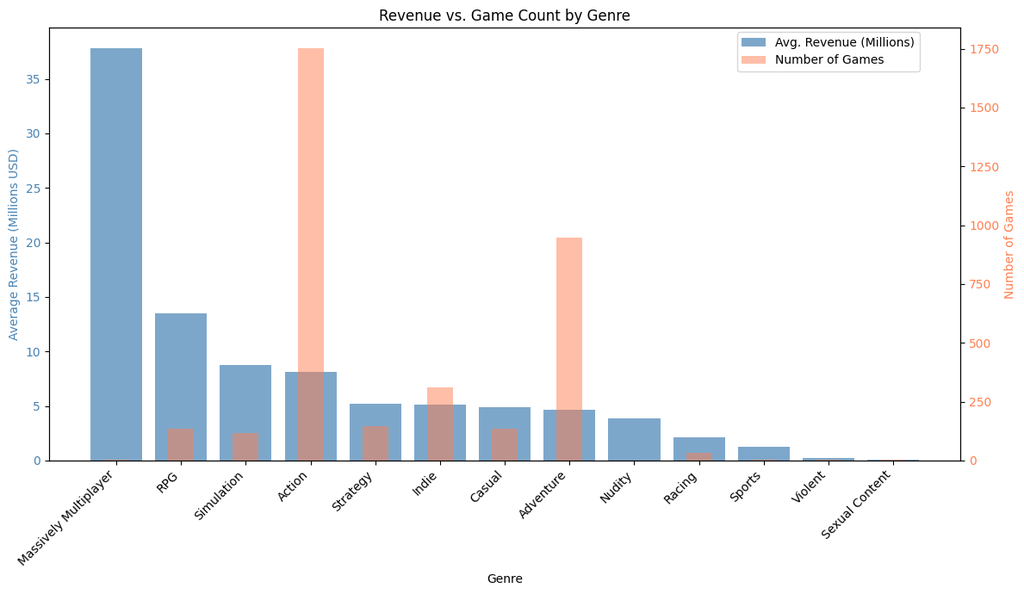

```
Genre Statistics:
                       revenue est  game_count
main genre
Massively Multiplayer  37791250.00           2
RPG                    13498281.99         136
Simulation              8791269.83         116
Action                  8150190.72        1751
Strategy                5184103.06         147
Indie                   5110773.79         309
Casual                  4844372.59         135
Adventure               4656873.18         947
Nudity                  3892500.00           1
Racing                  2096480.65          31
Sports                  1232216.67           3
Violent                  215925.00           4
Sexual Content            47525.00           2
```

```python
import matplotlib.pyplot as plt
import numpy as np

#Group by genre and calculate both metrics
genre_stats = joined2.groupby('main genre').agg({
    'revenue est': 'mean',
    'name': 'count'  #Count of games per genre
}).rename(columns={'name': 'game_count'}).sort_values('revenue est', ascending=False)

#Create figure with two y-axes
fig, ax1 = plt.subplots(figsize=(12, 7))

#Bar chart 1: Revenue (primary y-axis)
x_pos = range(len(genre_stats))
bars = ax1.bar(x_pos, genre_stats['revenue est'] / 1e6, color='steelblue', alpha=0.7, label='Avg. Revenue (Millions)')
ax1.set_xlabel('Genre')
ax1.set_ylabel('Average Revenue (Millions USD)', color='steelblue')
ax1.tick_params(axis='y', labelcolor='steelblue')
ax1.set_xticks(x_pos)
ax1.set_xticklabels(genre_stats.index, rotation=45, ha='right')

#Bar chart 2: Game Count (secondary y-axis)
ax2 = ax1.twinx()
ax2.bar(x_pos, genre_stats['game_count'], color='coral', alpha=0.5, width=0.4, label='Number of Games')
ax2.set_ylabel('Number of Games', color='coral')
ax2.tick_params(axis='y', labelcolor='coral')

#Add title and legend
plt.title('Revenue vs. Game Count by Genre')
fig.legend(loc='upper right', bbox_to_anchor=(0.9, 0.95))

plt.tight_layout()
plt.show()

#Print the data for reference
print("Genre Statistics:")
print(genre_stats[['revenue est', 'game_count']].round(2))
```

#### **Optimal game price point (sweet spot) to maximize revenue**

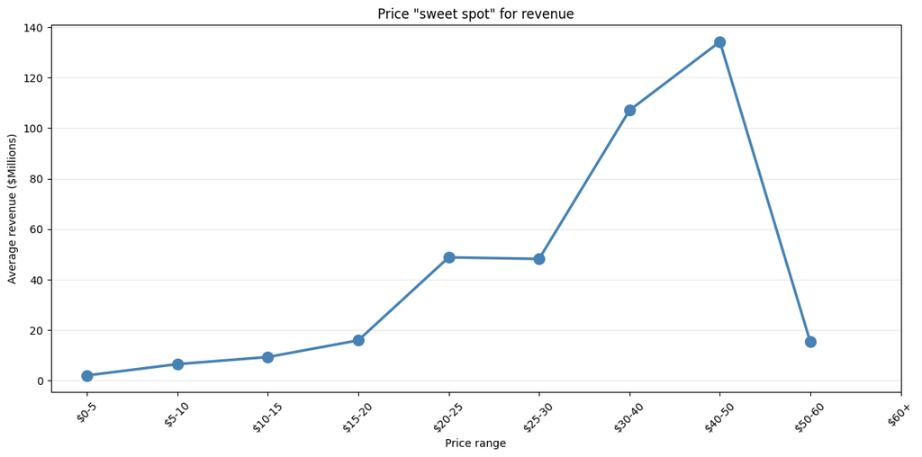

```
Revenue peaks at: $60+ ($nanM average)
```

```python
#Create price bins (more granular for better curve)
price_bins = [0, 5, 10, 15, 20, 25, 30, 40, 50, 60, 100]
price_labels = ['$0-5', '$5-10', '$10-15', '$15-20', '$20-25',
                '$25-30', '$30-40', '$40-50', '$50-60', '$60+']

joined2['price_bin'] = pd.cut(joined2['price'], bins=price_bins, labels=price_labels)

#Calculate average revenue per price bin
revenue_by_price = joined2.groupby('price_bin')['revenue est'].mean()

#Plot as a line with markers (like a curve)
plt.figure(figsize=(12, 6))
plt.plot(range(len(revenue_by_price)), revenue_by_price.values / 1e6,
         marker='o', linewidth=2.5, markersize=10, color='steelblue')

#Highlight the peak
peak_idx = revenue_by_price.values.argmax()
plt.scatter([peak_idx], [revenue_by_price.values[peak_idx] / 1e6],
            color='red', s=200, zorder=5, edgecolors='white', linewidth=2)
plt.annotate(f'SWEET SPOT!\n${revenue_by_price.index[peak_idx]}\nAvg Revenue: ${revenue_by_price.values[peak_idx]/1e6:.1f}M',
             xy=(peak_idx, revenue_by_price.values[peak_idx] / 1e6),
             xytext=(peak_idx + 1, revenue_by_price.values[peak_idx] / 1e6 + 5),
             arrowprops=dict(arrowstyle='->', color='red', lw=1.5),
             fontsize=10, fontweight='bold', ha='left')

plt.xticks(range(len(revenue_by_price)), revenue_by_price.index, rotation=45)
plt.xlabel('Price range')
plt.ylabel('Average revenue ($Millions)')
plt.title('Price "sweet spot" for revenue')
plt.grid(True, alpha=0.3, axis='y')
plt.tight_layout()
plt.show()

print(f"Revenue peaks at: {revenue_by_price.index[peak_idx]} (${revenue_by_price.values[peak_idx]/1e6:.1f}M average)")
```

#### **Top genres by revenue**

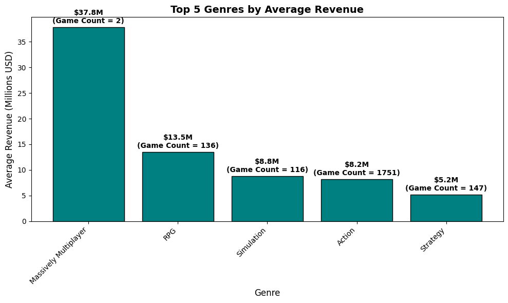

```
Top 5 Genres Revenue Breakdown:
                       revenue est  game_count
main genre
Massively Multiplayer  37791250.00           2
RPG                    13498281.99         136
Simulation              8791269.83         116
Action                  8150190.72        1751
Strategy                5184103.06         147
```

```python
#Get top 5 genres by average revenue
top_5_revenue = genre_stats.nlargest(5, 'revenue est')[['revenue est', 'game_count']]

fig, ax = plt.subplots(figsize=(10, 6))
bars = ax.bar(top_5_revenue.index, top_5_revenue['revenue est'] / 1e6, color='teal', edgecolor='black')

#Add value labels on bars
for bar, (genre, row) in zip(bars, top_5_revenue.iterrows()):
    height = bar.get_height()
    ax.text(bar.get_x() + bar.get_width()/2., height + 0.5,
            f'${height:.1f}M\n(Game Count = {int(row["game_count"])})', ha='center', va='bottom', fontweight='bold')

ax.set_xlabel('Genre', fontsize=12)
ax.set_ylabel('Average Revenue (Millions USD)', fontsize=12)
ax.set_title('Top 5 Genres by Average Revenue', fontsize=14, fontweight='bold')
ax.set_ylim(0, max(top_5_revenue['revenue est'] / 1e6) + 2)
plt.xticks(rotation=45, ha='right')
plt.tight_layout()
plt.show()

print("\nTop 5 Genres Revenue Breakdown:")
print(top_5_revenue.round(2))
```

#### **Steam game owner distribution**

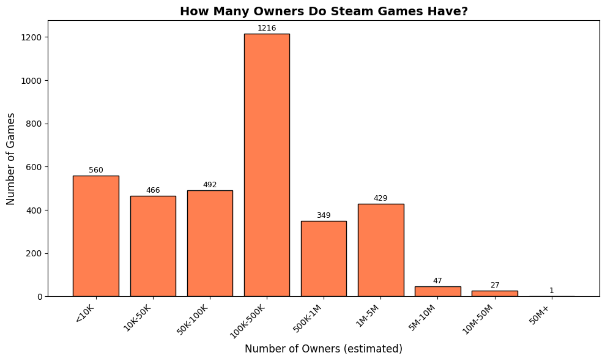

```
Owner Distribution Summary:
owner_range
<10K          560
10K-50K       466
50K-100K      492
100K-500K    1216
500K-1M       349
1M-5M         429
5M-10M         47
10M-50M        27
50M+            1
Name: count, dtype: int64
```

```python
#Create owner ranges (in millions)
joined2['owner_millions'] = joined2['owner est'] / 1_000_000

#Create bins for owners
owner_bins = [0, 0.01, 0.05, 0.1, 0.5, 1, 5, 10, 50, 100]
owner_labels = ['<10K', '10K-50K', '50K-100K', '100K-500K', '500K-1M',
                '1M-5M', '5M-10M', '10M-50M', '50M+']

joined2['owner_range'] = pd.cut(joined2['owner_millions'], bins=owner_bins, labels=owner_labels)

#Count games in each owner range
owner_counts = joined2['owner_range'].value_counts().sort_index()

plt.figure(figsize=(10, 6))
bars = plt.bar(owner_counts.index, owner_counts.values, color='coral', edgecolor='black')
plt.xlabel('Number of Owners (estimated)', fontsize=12)
plt.ylabel('Number of Games', fontsize=12)
plt.title('How Many Owners Do Steam Games Have?', fontsize=14, fontweight='bold')
plt.xticks(rotation=45, ha='right')

#Add value labels
for bar in bars:
    height = bar.get_height()
    plt.text(bar.get_x() + bar.get_width()/2., height + 5,
             f'{int(height)}', ha='center', va='bottom', fontsize=9)

plt.tight_layout()
plt.show()

print("\nOwner Distribution Summary:")
print(owner_counts)
```

# **Modeling**

## **Model 1: Revenue Prediction Model**

Can we predict a game's estimated revenue based on its genre, price, and metacritic score?

- **Features:** Main genre, price, metacriticScore
- **Dependent variable:** Revenue estimate
- **Method:** [Multiple Linear Regression](https://scikit-learn.org/stable/modules/generated/sklearn.linear_model.LinearRegression.html)
- **Why:** The data points (EDA) show variation in revenue across different genres and price ranges, which implies these features may be predictable.

```python
'''We'll start by using the game_stats dataframe defined in the EDA Part 2 section,
and merge it with metacriticScore from the first paid_games dataframe and the new
columns made in part 2 (est. owners and revenue). We'll create dummies for
main_genre since it's not a numerical value, then split into training and test
sets to evaluate using RMSE'''

from sklearn.linear_model import LinearRegression
from sklearn.model_selection import train_test_split
from sklearn.preprocessing import OneHotEncoder
from sklearn.metrics import r2_score, mean_squared_error

#Use game_stats merged with metacriticScore from games_paid
model1_df = game_stats.merge(
    games_paid[['name', 'appID', 'metacriticScore']], on=['name', 'appID'], how='inner'
).dropna(subset=['price', 'metacriticScore', 'revenue est', 'main genre'])

#Split main genre into dummies
genre_dummies = pd.get_dummies(model1_df['main genre'], prefix='genre')

#Create the feature matrix
X = pd.concat([
    model1_df[['price', 'metacriticScore']].reset_index(drop=True),
    genre_dummies.reset_index(drop=True)
], axis=1)

y = model1_df['revenue est'].reset_index(drop=True)

#80/20 train/test split
X_train, X_test, y_train, y_test = train_test_split(X, y, test_size=0.2, random_state=42)

#Fit the model
lr_model = LinearRegression()
lr_model.fit(X_train, y_train)

#Make the prediction and calculate r2 and rmse scores
y_pred = lr_model.predict(X_test)
r2 = r2_score(y_test, y_pred)
rmse = np.sqrt(mean_squared_error(y_test, y_pred))

print(f"R² Score:  {r2:.4f}")
print(f"RMSE:      ${rmse:,.0f}")
```

```
R² Score:  0.0685
RMSE:      $55,133,914
```

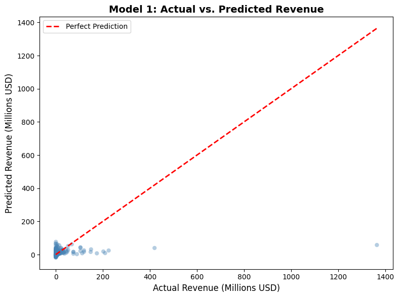

```python
#Now we can visualize it using plt

fig, ax = plt.subplots(figsize=(8, 6))
ax.scatter(y_test / 1e6, y_pred / 1e6, alpha=0.4, color='steelblue', edgecolors='none')
ax.plot([y_test.min() / 1e6, y_test.max() / 1e6],
        [y_test.min() / 1e6, y_test.max() / 1e6],
        'r--', linewidth=2, label='Perfect Prediction')
ax.set_xlabel('Actual Revenue (Millions USD)', fontsize=12)
ax.set_ylabel('Predicted Revenue (Millions USD)', fontsize=12)
ax.set_title('Model 1: Actual vs. Predicted Revenue', fontsize=14, fontweight='bold')
ax.legend()
plt.tight_layout()
plt.show()
```

### **Observations:**

Clearly the first model isn't a very good fit, but this makes sense given the question we are approaching and the dataset. Model 1 was a very simple model built on Multiple Linear Regression, and serves as a baseline for how the model can be improved in the second iteration. Being based on linear regression is a notable reason for why the model behaved so badly. Linear regression expects a linear relationship between features, a condition that is badly violated with extremely skewed target data. The genre imbalance amplifies this problem because the one hot encoded dummy columns for genre are highly imbalanced as well. A large portion of the dataset is action/adventure games, with outlying genres only having a few entries, meaning very sparse dummy columns. Since all the dummy columns get treated symmetrically in linear regression, the rare genres get unreliable coefficients thereby throwing off the entire model.

The graph shows a high concentration of data points in the bottom left corner, and then virtually no data in the rest of the graph except for a couple rare outliers with massive revenue. The R2 value is 0.0685 which is awful, but this makes sense because the data barely sticks to the perfect prediction line.

## **Model 2: Revised Revenue Prediction Model**

Can we predict a game's estimated revenue based on its genre, price, and metacritic score?

- **Features:** Main genre, price, metacriticScore
- **Dependent variable:** Revenue estimate (with log1p transformation to address right skew)
- **Method:** [LGBM Regressor](https://lightgbm.readthedocs.io/en/latest/pythonapi/lightgbm.LGBMRegressor.html)
- **Why:** Light GBM is useful because it handles skewed targets well, especially when used in tandem with log transformations. This will get less thrown off by the massive genre imbalance than a simpler algorithm like KNN. It also has native handling of categorical variables (no need to make dummies from genre), and built in feature importance which is a plus.

```python
import lightgbm as lgb
from sklearn.model_selection import train_test_split
from sklearn.metrics import r2_score, mean_squared_error
import numpy as np

#Use game_stats merged with metacriticScore from games_paid
model1_df = game_stats.merge(
    games_paid[['name', 'appID', 'metacriticScore']], on=['name', 'appID'], how='inner'
).dropna(subset=['price', 'metacriticScore', 'revenue est', 'main genre'])

#Uses log1p transformation to address the skew of the revenue variable, 1p is just the version that handles zeros safely
#Also needed to recast main genre as type category from object so that LGBMRegressor will accept it as the categorical variable
model1_df['log_revenue'] = np.log1p(model1_df['revenue est'])
model1_df['main genre'] = model1_df['main genre'].astype('category')
model1_df = model1_df.rename(columns={'main genre': 'main_genre'})

#Training off of genre, price, and metacritic score, predicting revenue
X = model1_df[['main_genre', 'price', 'metacriticScore']]
y = model1_df['log_revenue']

#Standard 80/20 train/test split, fits model with categorical feature parameter set to genre
X_train, X_test, y_train, y_test = train_test_split(X, y, test_size=0.2)
model = lgb.LGBMRegressor()
model.fit(X_train, y_train, categorical_feature = ['main_genre'])

#Make prediction then calculate r2 score and rmse
y_pred = model.predict(X_test)
r2 = r2_score(y_test, y_pred)
rmse = np.sqrt(mean_squared_error(y_test, y_pred))
print(" ")
print(f"R² Score:  {r2:.4f}")
print(f"RMSE:      ${rmse:,.0f} million")

#Calculate the feature importances from the built in data offered by the LGBM model, useful to assess how important genre is to the regression (spoiler, not very)
importance = pd.DataFrame({
    'feature': X.columns,
    'importance': model.feature_importances_
}).sort_values('importance', ascending=False)

display(importance)
```

```
[LightGBM] [Info] Auto-choosing col-wise multi-threading, the overhead of testing was 0.000545 seconds.
You can set `force_col_wise=true` to remove the overhead.
[LightGBM] [Info] Total Bins 196
[LightGBM] [Info] Number of data points in the train set: 2867, number of used features: 3
[LightGBM] [Info] Start training from score 13.482954

R² Score:  0.2995
RMSE:      $2 million
```

|  | feature | importance |
| --- | --- | --- |
| 1 | price | 1435 |
| 2 | metacriticScore | 1393 |
| 0 | main_genre | 172 |

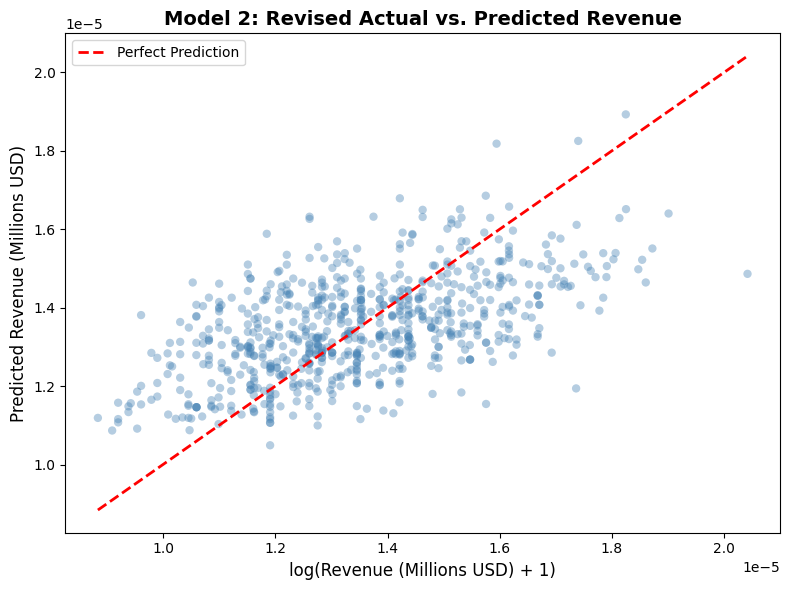

```python
#Now use plt to visualize the model's results, along with the perfect prediction line to evaluate how well our model is doing

fig, ax = plt.subplots(figsize=(8, 6))
ax.scatter(y_test / 1e6, y_pred / 1e6, alpha=0.4, color='steelblue', edgecolors='none')
ax.plot([y_test.min() / 1e6, y_test.max() / 1e6],
        [y_test.min() / 1e6, y_test.max() / 1e6],
        'r--', linewidth=2, label='Perfect Prediction')
ax.set_xlabel('log(Revenue (Millions USD) + 1)', fontsize=12)
ax.set_ylabel('Predicted Revenue (Millions USD)', fontsize=12)
ax.set_title('Model 2: Revised Actual vs. Predicted Revenue', fontsize=14, fontweight='bold')
ax.legend()
plt.tight_layout()
plt.show()
```

### **Observations:**

For the second model we chose a different algorithm and utilized additional data handling techniques to address the imbalance in our data. The two main imbalances we addressed were skew of revenue and dominance of action/adventure genres.

The large imbalance in revenue is because blockbuster games make millions of dollars while most games make significantly less. The price and metacritic score alone isn't much to differentiate between games because lots of games can have similar metacritic scores and price but not perform as well. However, msot games that have large revenues are expensive and famous games that either come from established studios or are continuations of game series. For this reason we hypothesize that price can still have a distinct correlation with revenue. To help scale the revenue feature we applied a log1p transformation before model fitting to reduce the impact that large outliers had on the overall model.

We specifically chose LGBMRegressor because it handles target data skew well, has native handling of categorical variables (no need to dummy encode), and has built in feature importance. It is a gradient boosted tree model meaning it is much better suited for non linear relationships than a traditional linear regression model. The native handling of categorical variables is also a plus because it allows the model to lean genre splits intelligently rather than treating each genre as it's own imbalanced dummy column. The built in feature importance is also a nice touch as it allows us to see the affect that genre (and other variables) has on the model, which was a very interesting metric and result.

As seen in the second figure, this model does a lot better than the first at accurately predicting revenue based on solely genre, price, and metacritic score. It makes sense that the accuracy slowly begins to drop off as the x axis grows because as revenues start entering the larger millions there begin to be a lot more outliers. These outliers often depend on factors not represented in our model such as sequel status, studio, and hype/popularity (such as when a relatively "normal" game goes viral, tops the charts, etc).

# **Conclusions**

Based on what we're able to derive from our models, there are a few conclusions that we arrived at. The first is that linear regression is not effective for this problem, as an R^2 of 0.0685 and RMSE of 55 million point to poor correlation. We also see that most of the data points are clustered near the bottom left of the scatterplot, which shows that the selected features and revenue do not have a simple linear relationship.

#### **IPYNB -> HTML Download**

```python
#Convert the notebook to html for hosting on GitHub
!jupyter nbconvert --to html /content/drive/MyDrive/Colab\ Notebooks/Final\ Notebook
```

```
[NbConvertApp] Converting notebook /content/drive/MyDrive/Colab Notebooks/Final Notebook to html
[NbConvertApp] WARNING | Alternative text is missing on 7 image(s).
[NbConvertApp] Writing 1103277 bytes to /content/drive/MyDrive/Colab Notebooks/Final Noteboo.html
```